# ALU Data Analyst Assessment

### Q2 b) Family income vs performance

| Income Level (USD) | Count | Mean Grade | Pass Rate (%) |
| --- | --- | --- | --- |
| 135-200 | 93 | 3.51 | 61.29 |
| 201-270 | 27 | 2.96 | 40.74 |
| 410+ | 5 | 2.80 | 40.00 |
| 271-340 | 16 | 2.50 | 37.50 |
| 341-410 | 4 | 2.00 | 50.00 |

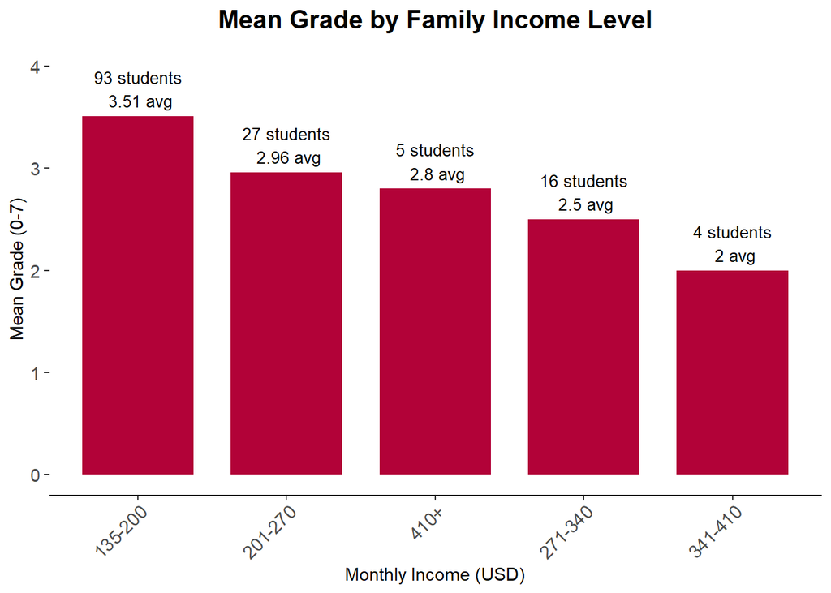

This pattern likely reflects confounding variables rather than a causal relationship. Students from lower-income backgrounds who gain university admission may represent a more academically selected group (having overcome significant barriers), while higher-income students may face fewer consequences for underperformance or have access to university regardless of academic preparedness. Alternatively, wealthier students may face fewer immediate pressures to succeed academically if family connections or resources provide alternative pathways.

**Key Insights: Socioeconomic Factors and Academic Performance** The relationship between financial support and academic performance reveals a **non-linear pattern** that challenges usual assumptions about funding and student success.